# Recalling Words

```r
# Play the chunk above and this one to get the data into your Console
View(Friendly)
?Friendly
datatable(Friendly, options=list(lengthMenu = c(3,10,30)))
Friendly$differences <- Friendly$correct[Friendly$condition=="Before"] -
  Friendly$correct[Friendly$condition=="Meshed"]

Friendly2 <- Friendly%>%
                  filter(condition %in% c("Meshed","Before"))
```

#### Background

Many teachers and other educators are interested in understanding how to best deliver new content to students. In general, they have two choices of how to do this.

1. The Meshed Approach
   - Deliver new content while simultaneously reviewing previously understood content.
2. The Before Approach
   - Deliver new content after fully reviewing previously understood content.

A study was performed to determine whether the *Meshed* or *Before* approaches to delivering content had any positive benefits on memory recall.

### Analysis

Since there were 2 different treatments in the experiment mentioned above, it is recommended to seek if there was a significant difference in the resulted produced by each treatment. In order to seek this, in this test the difference of the medians will be sought in order to see if the treatments produced similar results or if one produced more significant results than the other.

| Type | Words Recalled |
| --- | --- |
| Before | 24, 30, 37, 38, 39, 39, 39, 40, 40, 40 |
| Meshed | 30, 34, 36, 36, 36, 37, 38, 39, 40, 40 |

Our null hypothesis will be to check if the difference of the medians are equal in value. Formally written as

$$H_0: \text{difference in medians} = 0$$

The alternative hypothesis will be to measure if the difference of the medians differ in value. Formally written as

$$H_a: \text{difference in medians} \neq 0$$
The significance level for this test will set at

$$\alpha = 0.05$$

The boxplots displayed below portray that both conditions have a similar spread and therefore produced similar results in terms of words recollected through the conditions.

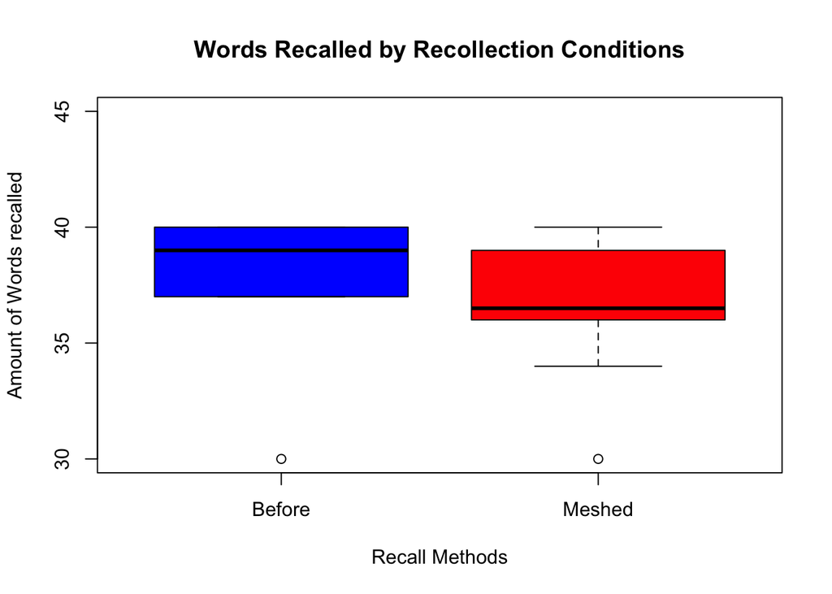

```r
boxplot(Friendly$correct[Friendly$condition=="Before"], Friendly$correct[Friendly$condition=="Meshed"],
       ylim=c(30,45), main="Words Recalled by Recollection Conditions", ylab="Amount of Words recalled", xlab="Recall Methods", col=c("blue","red"), names=c("Before","Meshed"))
```

The values displayed in the boxplots are displayed in the table below.

```r
Friendly2 <- Friendly%>%
                  filter(condition %in% c("Meshed","Before"))

friend_sum <- Friendly2 %>%
  group_by(condition) %>%
  summarise(Min=min(correct),
            Q1=quantile(correct,0.25),
            Median=median(correct),
            Q3=quantile(correct,0.75),
            Max=max(correct))

pander(friend_sum)
```

| condition | Min | Q1 | Median | Q3 | Max |
| --- | --- | --- | --- | --- | --- |
| Before | 24 | 37.25 | 39 | 39.75 | 40 |
| Meshed | 30 | 36 | 36.5 | 38.75 | 40 |

Through the table displayed above, it may be assumed that the before condition is more effective in recollection of words because it produced a higher median of words recalled. In order to verify that this is a reasonable conclusion for the general population, a Wilcoxon Rank Sum Test will be used. The sample sizes for each group are equivalent to each other and they do not differ enough to miss assumptions of spread and identical shape needed to satisfy the requirements of a Rank Sum Test.

```r
pander(wilcox.test(correct~condition, data=Friendly2))
```

Wilcoxon rank sum test with continuity correction: `correct` by `condition`

| Test statistic | P value | Alternative hypothesis |
| --- | --- | --- |
| 62 | 0.378 | two.sided |